# HW3

Jennifer Freeman

27/09/2021

```r
# tried tabulizer package, extract_tables and extract_areas
# returned mostly garbage, possibly because the table is rotated in the pdf
# dat <- extract_areas("HW3/Curtis_etal_2019.pdf", pages = 6, method = "stream")

# resorted to copying table from web and saving as a txt file

# tried to read in existing column names as character vectors
# ##first header
#  (dat1 <- read_tsv("blueberries.txt", n_max=0)
#   %>% names()
#  )
# ##second  header
#  (dat2 <- read_tsv("blueberries.txt", skip=1, n_max=0)
#   %>% names()
#  )
#
# for second header, had trailing "...#" after each column name even though
# there was no trailing characters in the txt file
# couldn't find any solutions


# decided to manually type out column names
# data groupings
treat_time <- read.table(header = TRUE, text="
Treatment Time
Placebo Before
HalfCup After
OneCup Diff
")

# expand data groupings, order, and combine
treat_time2 <- (treat_time
  %>% expand(Treatment, Time) # get all combinations of Treatment and Time
  %>% arrange(match(Time, c("Before", "After", "Diff"))) # custom order Time to match data set
  %>% arrange(match(Treatment, c("Placebo", "HalfCup", "OneCup" ))) # custom order Treatment to match data set
  %>% unite("Treatment.Time", 1:2, sep = ".",) # combine Treatment and Time variables
)

# add additional column names, and transpose
cnames <- c("Parameter", t(treat_time2), "P")

# read in txt file
dat <- (read_tsv("blueberries.txt"
                 , skip = 2
                 , col_names = cnames # name columns with cnames
                 )
  # pivot longer all columns with confidence intervals
  %>% pivot_longer(cols = -c("Parameter","P") , names_to = "Treatment.Time", values_to = "val")
  # move second set of data values for HbA1c into new rows
  %>% separate_rows(val, sep = "\\;")
  %>% mutate(Parameter = case_when(startsWith(val, " [") ~ "HbA1c, (mmol/mol)"# rename parameter values for both HbA1c values
                                   , str_detect(Parameter, "%") ~ "HbA1c, %"
                                   , TRUE ~ Parameter)
             , val = str_replace_all(val, "\\[|\\]", ""), # remove square brackets
             , val = str_trim(val, side = "left") # remove leading spaces
             )
  # separate confidence intervals out
  %>% separate(val, into = c("Mean", "L_CI", "U_CI"), sep = "\\(|\\,")
  %>% mutate(U_CI = as.numeric(str_remove(U_CI, "\\)[:print:]*$")) # remove trailing brackets and characters, convert to numeric
             , Mean = as.numeric(str_replace(Mean, "–", "-")) # replace en dash with minus, convert to numeric
             , L_CI = as.numeric(str_replace(L_CI, "–", "-")) # replace en dash with minus, convert to numeric
             )
   # separate treatment and time out
  %>% separate(Treatment.Time, into = c("Treatment", "Time"), sep = "\\.")
)
# data with time difference removed
dat2 <- (dat
        %>% filter(Time != "Diff")

)

# data with parameter names ordered by mean time difference for the one cup treatment group
dat3<- (dat
        %>% filter(Time == "Diff", Treatment == "OneCup")
        %>% arrange(Mean)
        %>% distinct(Parameter)
)

#data with only mean time difference data
dat4 <- (dat
         %>% filter(Time == "Diff")
)
```

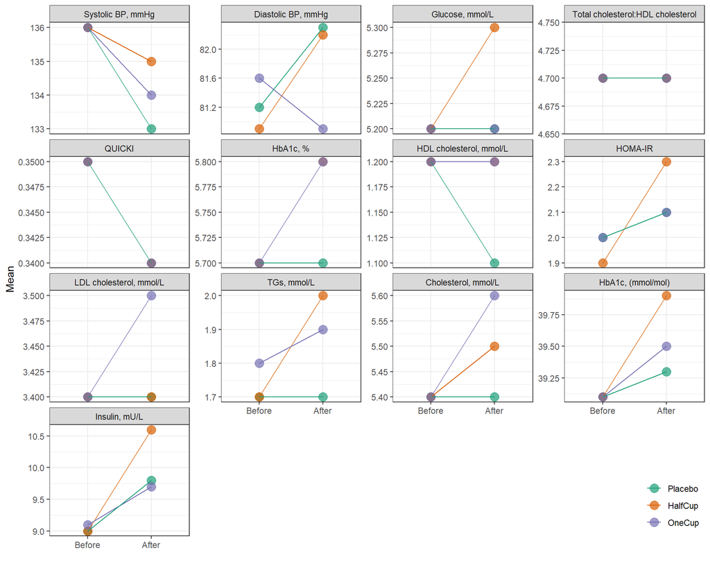

```r
gg1 <- (ggplot(dat2, aes(y = Mean, x = factor(Time, levels = c("Before", "After")),
                       colour = factor(Treatment, levels = c("Placebo", "HalfCup", "OneCup"))))
      + geom_point(aes(group = Treatment), size=4, alpha=0.7)
      + geom_line(aes(group = Treatment))
      + facet_grid(cols = vars(factor(Parameter,
                                      levels = t(dat3))))# use ordering from dat3
      + facet_wrap(~ factor(Parameter,
                            levels = t(dat3)),# use ordering from dat3
                   nrow=4,
                   scales="free_y") # individual y scales
      + theme_bw()
      + theme(legend.position = c(1,0),
              legend.justification = c(1, 0),
              legend.title = element_blank())
      + scale_color_brewer(palette = "Dark2")
      + labs(x = "")
      )

print(gg1)
```

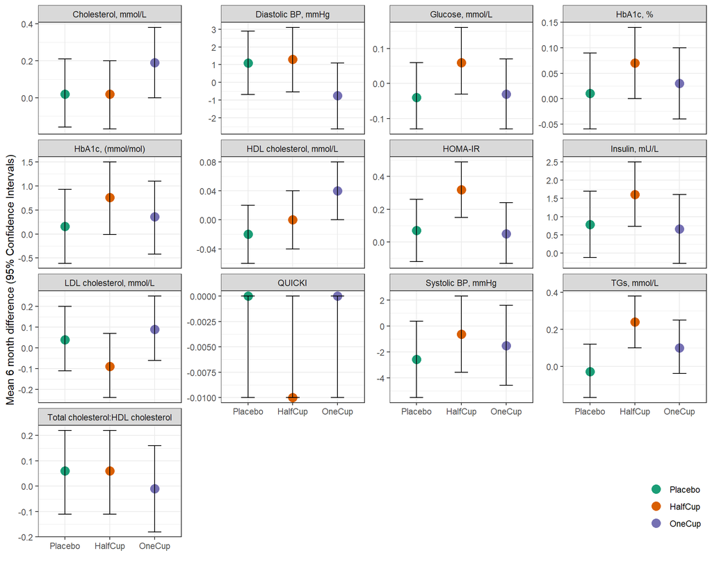

```r
gg2 <- (ggplot(dat4, aes(y = Mean, x = factor(Treatment, levels = c("Placebo", "HalfCup", "OneCup"))))
      + geom_point(aes(group = Treatment,
                       colour = factor(Treatment, levels = c("Placebo", "HalfCup", "OneCup"))),
                   size=4
                   )
      + geom_errorbar(aes(ymin=L_CI, ymax=U_CI), width=0.3) # Use CI for error bars
      + facet_grid(cols = vars(factor(Parameter)))
      + facet_wrap(~ factor(Parameter), nrow=4, scales="free_y")
      + theme_bw()
      + theme(legend.position = c(1,0),
              legend.justification = c(1, 0),
              legend.title = element_blank())
      + scale_color_brewer(palette = "Dark2")
      + labs(x = "", y="Mean 6 month difference (95% Confidence Intervals)")
      )

print(gg2)
```

Table 2 in **[1]** displays mean parameter values that were measured at 0 and 6 months for three treatment groups: Placebo, 1/2 cup blueberries/day and 1 cup of blueberries/day .

In the first plot I am trying to draw attention to the change in mean parameter values for each treatment group over the six month interval. I attempted to order the parameters in order of mean 6 month difference for the *OneCup* treatment group, but the order doesn’t appear to be very meaningful. I wanted to display an ordering of the parameters that would range from decreasing slopes to increasing. The plot is maybe a little misleading because the largest changes for each parameter are depicted with the same slope and could be confusing unless you pay attention to the scales.

In the second plot, I am trying compare the mean differences with 95% confidence intervals for each treatment group. It is much faster to view these values versus read them in a table and it can highlight interesting things. For example, the *HalfCup* treatment group looks on average different that then *Placebo* group for the TGs parameter.

It might also be worth exploring this data by combining parameters that share the same units in one plot.

### References

**[1]** Peter J Curtis, Vera van der Velpen, Lindsey Berends, Amy Jennings, Martin Feelisch, A Margot Umpleby, Mark Evans, Bernadette O Fernandez, Mia S Meiss, Magdalena Minnion, John Potter, Anne-Marie Minihane, Colin D Kay, Eric B Rimm, Aedín Cassidy, Blueberries improve biomarkers of cardiometabolic function in participants with metabolic syndrome—results from a 6-month, double-blind, randomized controlled trial, The American Journal of Clinical Nutrition, Volume 109, Issue 6, June 2019, Pages 1535–1545, https://doi.org/10.1093/ajcn/nqy380